# Örnek Proje

Bu doküman istatistik dersinde öğrencilerin yapacakları projelerde yardımcı olmak için hazırlanmıştır.

# 1 Projenin Konusu ve Amacı

Bu projede farklı araç tiplerinin yakıt tüketimleri ile ilgili istatistiksel analizler yapılacaktır. Bu amaçla, `tidyverse` paketi içinde yer alan `mpg` veri seti kullanılacaktır. Bu veri seti 1999-2008 yılları arasında üretilen otomobillerin yakıt ekonomisi ile ilgili verileri içermektedir. Bu veri setini kullanabilmek için tidyverse paketinin aktif `library()` fonksiyonu ile aktif hale getirilmesi gereklidir.

```r
library(tidyverse)
```

İlk olarak `head()` fonksiyonu ile bu veri setindeki ilk 6 gözleme ulaşarak bu gözlemleri tablo formatında yazdıralım. Tablo oluşturmak için `knitr` paketi içindeki `kable()` fonksiyonununu kullanabiliriz. ile değişkenleri ve bu değişkenlerdeki gözlemleri tablo formatında yazdırabiliriz. Bu tabloya `caption` seçeneği ile bir açıklama yazısıda ekleyebiliriz.

```r
head(mpg)%>%
    knitr:: kable(caption = "mpg veri seti")%>%
    kableExtra::kable_classic(full_width=FALSE)
```

mpg veri seti

| manufacturer | model | displ | year | cyl | trans | drv | cty | hwy | fl | class |
| --- | --- | --- | --- | --- | --- | --- | --- | --- | --- | --- |
| audi | a4 | 1.8 | 1999 | 4 | auto(l5) | f | 18 | 29 | p | compact |
| audi | a4 | 1.8 | 1999 | 4 | manual(m5) | f | 21 | 29 | p | compact |
| audi | a4 | 2.0 | 2008 | 4 | manual(m6) | f | 20 | 31 | p | compact |
| audi | a4 | 2.0 | 2008 | 4 | auto(av) | f | 21 | 30 | p | compact |
| audi | a4 | 2.8 | 1999 | 6 | auto(l5) | f | 16 | 26 | p | compact |
| audi | a4 | 2.8 | 1999 | 6 | manual(m5) | f | 18 | 26 | p | compact |

Tablodaki değişkenlerin açıklamaları aşağıdaki gibidir

- `manufacturer:` Üretici
- `model:` Aracın modeli
- `displ:` Motor hacmi
- `year:` Üretim yılı
- `cyl:` silindir sayısı
- `trans:` Vites tipi (manuel veya otomatik)
- `drv:` Çekiş tipi (önden çekişli, arkadan çekişli veya 4x4)
- `cty:` Şehir içi yakıt tüketimi
- `hwy:` Şehir dışı yakıt tüketimi
- `fl:` Yakıt tipi (e: etonol, p:premum yakıt, d: dizel, c: CNC, r=normal (regular))
- `class:` Sınıf

## 1.1 Verilerin Temizlenmesi

İstatisitksel analizler için toplanan veriler çoğu zaman doğrudan kullanıma hazır değildir. Verilerin toplanması veya bilgisayara aktarılması sırasında yazım hataları, eksik gözlemler, analizlerde kullanılmayacak değişkenlere ait gözlemler bulunabilir. Analizler için gerekli ancak veriler toplanırken dikkate alınmayan değişkenlerinde veri setine eklenmesi gereklidir. Ayrıca, veriler okunurken değişken R tarafından otomatik olarak belirlenen veri tipleri yanlış veya uygun tipte olmayabilir. Bu nedenle analizlere başlamadan önce veri içindeki hataların düzeltilmesi, eksik gözlemlerin silinmesi, fazla değişkenlerin silinmesi, yeni değişkenlerin eklenmesi, değişken tiplerinin uygun hale getirilmesi gibi işlemlerin yapılması gerekmektedir. Bu işlemler veri temizleme olarak isimlendirilir.

### 1.1.1 Değişken Tiplerinin Değiştirilmesi

Veri setindeki değişken tiplerinin istatistiksel analizler yapmak veya grafikler çizmek için uygun hale getirilmesi gereklidir. Mevcut veri setindeki değişkenlerin tiplerini `str()` fonksiyonu ile görebiliriz.

```r
str(mpg)
```

```
## tibble [234 x 11] (S3: tbl_df/tbl/data.frame)
##  $ manufacturer: chr [1:234] "audi" "audi" "audi" "audi" ...
##  $ model       : chr [1:234] "a4" "a4" "a4" "a4" ...
##  $ displ       : num [1:234] 1.8 1.8 2 2 2.8 2.8 3.1 1.8 1.8 2 ...
##  $ year        : int [1:234] 1999 1999 2008 2008 1999 1999 2008 1999 1999 2008 ...
##  $ cyl         : int [1:234] 4 4 4 4 6 6 6 4 4 4 ...
##  $ trans       : chr [1:234] "auto(l5)" "manual(m5)" "manual(m6)" "auto(av)" ...
##  $ drv         : chr [1:234] "f" "f" "f" "f" ...
##  $ cty         : int [1:234] 18 21 20 21 16 18 18 18 16 20 ...
##  $ hwy         : int [1:234] 29 29 31 30 26 26 27 26 25 28 ...
##  $ fl          : chr [1:234] "p" "p" "p" "p" ...
##  $ class       : chr [1:234] "compact" "compact" "compact" "compact" ...
```

Yukarıdaki listede mpg veri setinde yer alan değişkenlerin isimleri, tipleri, gözlem sayıları ve birkaç örnek gözlem verilmektedir. R sözel ifadeleri içeren değişkenleri `chr`, tamsayıları içeren değişkenleri `int` ve ondalıklı sayıları içeren değişkenleri ise `num` olarak belirler. `chr` tipinde olan değişkenleri `Factor` tipine dönüştürmek grafiklerin çizilmesinde ve istatisitsel analizlerin yapılmasında kolaylık sağlamaktadır. Bu nedenle `chr` tipindeki değişkenleri `Factor` tipine dönüştürülmesi gerekir. `as.factor()` fonksiyonu ile bir değişkenin tipi `Factor` tipine dönüştürülebilir. Örneğin `trans` değişkenini faktör tipine dönüştürmek için aşağıdaki komutu kullanabiliriz.

```r
mpg$trans<-as.factor(mpg$trans)
```

Karakter tipindeki değişkenlerin tümünü fakör tipine dönüştürmek için dplyr paketi içindeki `mutate_if()` fonksiyonunu kullanabiliriz.

```r
mpg <- mpg %>% mutate_if(is.character, as.factor)
```

Veri setinde bazı değişkenler sayısal değer almasına rağmen bu değişkenler aslında kategorik nitelikte olabilir. Örneğin, mpg veri setinde `year` ve `cyl` değişkenleri araçların üretim yıllarına ve silindir sayılarına göre sınıflandırmak için kullanılan değişkenlerdir. Bu değişkenler üzerinden aritmatik işlemler yapılmayacağından dolayı bu değişkenleri de faktör tipine dönüştürebiliriz.

```r
mpg$year<-as.factor(mpg$year)
mpg$cyl<-as.factor(mpg$cyl)
```

Bu işlemler sonucunda değişken tipleri aşağıdaki gibi düzenlenmiş olur.

```r
str(mpg)
```

```
## tibble [234 x 11] (S3: tbl_df/tbl/data.frame)
##  $ manufacturer: Factor w/ 15 levels "audi","chevrolet",..: 1 1 1 1 1 1 1 1 1 1 ...
##  $ model       : Factor w/ 38 levels "4runner 4wd",..: 2 2 2 2 2 2 2 3 3 3 ...
##  $ displ       : num [1:234] 1.8 1.8 2 2 2.8 2.8 3.1 1.8 1.8 2 ...
##  $ year        : Factor w/ 2 levels "1999","2008": 1 1 2 2 1 1 2 1 1 2 ...
##  $ cyl         : Factor w/ 4 levels "4","5","6","8": 1 1 1 1 3 3 3 1 1 1 ...
##  $ trans       : Factor w/ 10 levels "auto(av)","auto(l3)",..: 4 9 10 1 4 9 1 9 4 10 ...
##  $ drv         : Factor w/ 3 levels "4","f","r": 2 2 2 2 2 2 2 1 1 1 ...
##  $ cty         : int [1:234] 18 21 20 21 16 18 18 18 16 20 ...
##  $ hwy         : int [1:234] 29 29 31 30 26 26 27 26 25 28 ...
##  $ fl          : Factor w/ 5 levels "c","d","e","p",..: 4 4 4 4 4 4 4 4 4 4 ...
##  $ class       : Factor w/ 7 levels "2seater","compact",..: 2 2 2 2 2 2 2 2 2 2 ...
```

### 1.1.2 Gözlemlerin Düzenlenmesi

Gözlemlerin toplanması veya bilgisayara aktarılması sırasında veri setinde birtakım hatalar oluşabilmektedir. Özellikle kategorik değişkenlerde yazım hataları ile sık sık karşılaşılmaktadır. Bu hataların tespit edilmesi ve doğru değerleri ile yerleştirilmesi gerekmektedir.

Örneğin `mpg` veri setinde `trans` değişkeni altında vites tiplerinin daha detaylı bir şekilde girildiği görülmektedir. Bu detay bilgiler gerekli değil ise vites tiplerini genel olarak *otomatik* ve *manuel* olmak üzere iki grup altında toplayabiliriz. Bu değişkendeki gözlemler “auto” veya “manual” kelimelerini içermektedir. Bu nedenle ilk harfi “a” olan gözlemleri “auto” diğerlerini ise “manual” olarak değiştirebiliriz. Bu işlemi `ifelse()` ve `substring()`fonksiyonlarını kullanarak yapabiliriz. `ifelse()` fonksiyonu verilen bir koşul doğru ise bir ifadenin değilse diğer ifadenin yapılmasını sağlamaktadır. `substring()` fonksiyonu ise bir metin dizisi içinde ilk ve son değerler arasında yer alan karakter dizisini vermektedir.

```r
mpg$trans <- ifelse(substring(mpg$trans, first=1, last=1)== "a", "auto", "manual") %>%as.factor()
```

### 1.1.3 Değişkenlerin Silinmesi ve Yeni Değişken Eklenmesi

Bazı veri setlerinde analizlerde kullanılmayacak değişkenler bulunabilir. Bu değişkenleri silinmesi isteniyor ise bunun için farklı yöntemler kullanılabilir. Birinci olarak, silinecek değişkenlere `NULL` ataması yapılabilir.

```r
# manufacturer değişkenini silmek için
mpg$manufacturer <- NULL

# 1. sıradaki değişkeni silmek için
mpg[1] <- NULL

# 1, 3 ve 4. sıradaki değişkenleri silmek için
mpg[c(1,3,4)] <- NULL
```

İkinci olarak değişkenin veri setinde yer aldığı sütun numarasının önüne `-` işareti konulabilir.

```r
# 2. sıradaki değişkeni silmek için
mpg <- mpg[-2]
```

Üçüncü olarak, değişkenleri silmek yerine sadece gerekli değişkenler seçilebilir.

```r
# veri setinde 3., 10. ve 11. sıradaki değişkenler dışında diğer değişkenlerin silmek için
mpg <- mpg[c(3,10,11)]
```

Değişkenlerin seçimini dplyr paketindeki `select()` fonksiyonu kullanarak yapılabilir.

```r
# cyl ve drv sütunlarını seçmek için
mpg<-mpg %>% select(cyl, drv)
```

Mevcut veri setinde yer almayan fakat analizler için gerekli değişkenlerin hesaplanması ve/veya başka bir veri setinden kopyalanması gerekebilir. Yeni bir değişken için yeni bir sütun veri seti ismi ile yeni değişkenin ismi arasına $ işareti konularak oluşturulabilir. Örneğin, `mpg` veri setine ortalama yakıt tüketimi için `mean_mpg` isminde yeni bir sütun oluşturmak için `mpg$mean_mpg` kullanılabilir. Ortalama yakıt tüketimi hesaplanırken şehir içi yakıt tüketiminin %70’i ve şehir dışı yakıt tüketimin %30’u alınmaktadır.

```r
mpg$mean_mpg <- 0.7*mpg$cty + 0.3*mpg$hwy
knitr:: kable(head(mpg, 6))%>%
  kable_classic(full_width=FALSE)
```

| manufacturer | model | displ | year | cyl | trans | drv | cty | hwy | fl | class | mean_mpg |
| --- | --- | --- | --- | --- | --- | --- | --- | --- | --- | --- | --- |
| audi | a4 | 1.8 | 1999 | 4 | auto | f | 18 | 29 | p | compact | 21.3 |
| audi | a4 | 1.8 | 1999 | 4 | manual | f | 21 | 29 | p | compact | 23.4 |
| audi | a4 | 2.0 | 2008 | 4 | manual | f | 20 | 31 | p | compact | 23.3 |
| audi | a4 | 2.0 | 2008 | 4 | auto | f | 21 | 30 | p | compact | 23.7 |
| audi | a4 | 2.8 | 1999 | 6 | auto | f | 16 | 26 | p | compact | 19.0 |
| audi | a4 | 2.8 | 1999 | 6 | manual | f | 18 | 26 | p | compact | 20.4 |

Ortalama yakıt tüketimi için yeni bir sütun eklemek için alternatif olarak `dplyr` paketi içindeki `mutate()` fonksiyonunu kullanabiliriz.

```r
mpg <- mpg%>%mutate(mean_mpg=0.7*cty+0.3*hwy)
```

### 1.1.4 Eksik Gözlemlerin Silinmesi

Veri setlerinde bazı gözlemlere giriş yapılamadığı veya unutulduğu için boş bırakılmış olabilir. R ile veriler okunurken tüm boşluklar eksik gözlem olarak değerlendirilir ve bu gözlemler `NA` şeklinde etiketlendirilir. Eksik gözlemler barındıran veri setlerinde nasıl bir yaklaşım izleneceği önceden belirlenmelidir. Veri setinin büyüklüğüne ve eksik gözlem saysına bağlı olarak eksik gözlemler tamamen veya kısmen silinebilir. Eksik gözlemlerin silinmesi zorunlu olmadıkça tercih edilmemelidir. Bunun yerine, analizler sırasında eksik gözlemleri dikkate almamak, veri kaybının önüne geçeceği için tercih edilmelidir. Bu amaçla, pek çok R fonksiyonunda yer alan `na.rm` seçeneği `na.rm=TRUE` şeklinde belirtilir ise eksik gözlemler analiz sırasında çıkarılmaktadır. Örneğin ortalamaları hesaplamak için kullanılan `mean()` fonksiyonunda `na.rm=TRUE` olarak belirtilir ise eksik gözlemler ortalamaya dahil edilmezler.

```r
mean(mpg$cyl, na.rm = TRUE)
```

Eksik gözlemleri silmek yerine diğer bir seçenek eksik gözlemlerin alacağı değerleri tahmin etmektir. Özellikle küçük veri setlerinde bu yöntem tercih edilmelidir. Sayısal değişkenlerdeki eksik gözlemleri tahmin etmek için aritmetik ortalama veya medyan gibi basit istatistikler, kategorik değişkenlerde ise mod (en sık tekrar eden değer) kullanılabilir. Bu basit istatistikler yerine daha karmaşık tahmin yöntemleri de kullanılabilir.

Veri setinde veya bir değişkende eksik gözlem olup olmadığını kontrol etmek için `is.na()` fonksiyonu kullanabiliriz. Bu fonksiyon eksik gözlemler için `TRUE` diğer durumda `FALSE` sonucunu vermektedir.

```r
a=c(1,NA,4)
is.na(a)
```

```
## [1] FALSE  TRUE FALSE
```

Bir veri setinde kaç tane eksik veri olduğunu bulmak için ise `sum()` fonksiyonunu kullanabiliriz. `sum()` fonksiyonu `TRUE` veya `FALSE` gibi mantıksal değerleri içeren dizilerde `TRUE` sayısını vermektedir.

```r
sum(is.na(c(1,NA,4)))
```

```
## [1] 1
```

mpg veri setinde eksik gözlem olup olmadığını belirlemek için aşağıdaki komutu kullanabiliriz.

```r
sum(is.na(mpg))
```

```
## [1] 0
```

Her değişkendeki eksik gözlemleri görmek için aşağıdaki komutu kullanarak eksik olan gözlemlerin sayısını tablo olarak yazdırabiliriz.

```r
summary(is.na(mpg))%>%
  kable()%>%
  kable_classic()
```

|  | manufacturer | model | displ | year | cyl | trans | drv | cty | hwy | fl | class | mean_mpg |
| --- | --- | --- | --- | --- | --- | --- | --- | --- | --- | --- | --- | --- |
|  | Mode :logical | Mode :logical | Mode :logical | Mode :logical | Mode :logical | Mode :logical | Mode :logical | Mode :logical | Mode :logical | Mode :logical | Mode :logical | Mode :logical |
|  | FALSE:234 | FALSE:234 | FALSE:234 | FALSE:234 | FALSE:234 | FALSE:234 | FALSE:234 | FALSE:234 | FALSE:234 | FALSE:234 | FALSE:234 | FALSE:234 |

Bu tabloda tüm değişkenler için **FALSE=234** olduğundan mpg veri setinde eksik gözlem bulunmamaktadır.

Bir veri setinde yer alan eksik gözlemlerin tümünü silmek için `na.omit()` fonksiyonu kullanılabilir.

```r
mpg<-mpg%>%na.omit()
```

Bir veya daha fazla sütunda bulunan eksik verileri silmek için dblyr paketi içinde yer alan `drop_na()` fonksiyonu kullanılabilir. Örneğin `cyl` ve `hwy` değişkenleri içindeki eksik gözlemleri silmek için aşağıdaki komutu kullanabiliriz.

```r
mpg%>%drop_na(cyl,hwy)
```

### 1.1.5 Gözlemlerin Dağılımındaki Dengesizliklerin Tespit Edilmesi

```r
mpg%>%
    select(cyl)%>%
    group_by(cyl)%>%
    summarise(sayı=n())%>%
  knitr::kable()%>%
  kable_classic(full_width=FALSE)
```

| cyl | sayı |
| --- | --- |
| 4 | 81 |
| 5 | 4 |
| 6 | 79 |
| 8 | 70 |

```r
summary(mpg%>%
  select_if(is.factor))
```

```
##      manufacturer                 model       year     cyl       trans
##  dodge     :37    caravan 2wd        : 11   1999:117   4:81   auto  :157
##  toyota    :34    ram 1500 pickup 4wd: 10   2008:117   5: 4   manual: 77
##  volkswagen:27    civic              :  9              6:79
##  ford      :25    dakota pickup 4wd  :  9              8:70
##  chevrolet :19    jetta              :  9
##  audi      :18    mustang            :  9
##  (Other)   :74    (Other)            :177
##  drv     fl             class
##  4:103   c:  1   2seater   : 5
##  f:106   d:  5   compact   :47
##  r: 25   e:  8   midsize   :41
##          p: 52   minivan   :11
##          r:168   pickup    :33
##                  subcompact:35
##                  suv       :62
```

Yukarıdaki sonuçlar incelendiğinde bazı kategorik değişkenler içinde bulunan alt kotegorilerdeki gözlemlerin dağılımlarının dengeli olmadığı görülmektedir. Örneğin `cyl`, `drv` ve `fl` kategorik değişkenlerindeki seviyelerde gözlemlerin dengeli bir şekilde dağılmadığı görülmektedir.

Bir veya daha fazla sütun bazında gözlemlerin dağılımını görmek için dplyr içindeki `group_by()` ve `summarise()` fonksiyonlarını kullanabiliriz. Örneğin, üretici ve model sayılarına göre gözlemlerin dengeli bir şekilde dağılıp dağılmadığını görmek için aşağıdaki komutu kullanabiliriz.

```r
mpg%>%
  group_by(manufacturer,model)%>%
  summarise(Gozlem_sayisi=n())%>%
  kable(col.names=c("Üretici","Model","Gözlem Sayısı"))%>%
  kable_classic(full_width=FALSE)
```

| Üretici | Model | Gözlem Sayısı |
| --- | --- | --- |
| audi | a4 | 7 |
| audi | a4 quattro | 8 |
| audi | a6 quattro | 3 |
| chevrolet | c1500 suburban 2wd | 5 |
| chevrolet | corvette | 5 |
| chevrolet | k1500 tahoe 4wd | 4 |
| chevrolet | malibu | 5 |
| dodge | caravan 2wd | 11 |
| dodge | dakota pickup 4wd | 9 |
| dodge | durango 4wd | 7 |
| dodge | ram 1500 pickup 4wd | 10 |
| ford | expedition 2wd | 3 |
| ford | explorer 4wd | 6 |
| ford | f150 pickup 4wd | 7 |
| ford | mustang | 9 |
| honda | civic | 9 |
| hyundai | sonata | 7 |
| hyundai | tiburon | 7 |
| jeep | grand cherokee 4wd | 8 |
| land rover | range rover | 4 |
| lincoln | navigator 2wd | 3 |
| mercury | mountaineer 4wd | 4 |
| nissan | altima | 6 |
| nissan | maxima | 3 |
| nissan | pathfinder 4wd | 4 |
| pontiac | grand prix | 5 |
| subaru | forester awd | 6 |
| subaru | impreza awd | 8 |
| toyota | 4runner 4wd | 6 |
| toyota | camry | 7 |
| toyota | camry solara | 7 |
| toyota | corolla | 5 |
| toyota | land cruiser wagon 4wd | 2 |
| toyota | toyota tacoma 4wd | 7 |
| volkswagen | gti | 5 |
| volkswagen | jetta | 9 |
| volkswagen | new beetle | 6 |
| volkswagen | passat | 7 |

## 1.2 İstatistiklerin Hesaplanması

Veri setindeki değişkenlerin frekansları, ortalamaları, vb. istatistikler veri seti hakkında genel bilgiler elde etmek ve gözden kaçan hataları tespit etmek için analizler öncesinde mutlaka hesaplanmalı ve kontrol edilmelidir. Bu amaçla R’deki `summary()` fonksiyonu kullanılabilir. Bu fonksiyon veri setindeki değişkenlerin tipine bağlı olarak özet istatistikleri verir. Sayısal değişkenler ortalama, medyan, 1.çeyrek, 3. çeyrek, minimum ve maksimum değerleri diğer değişken tipleri için ise frekanslar verilir.

```r
summary(
  mpg%>%select_if(is.numeric)
  )%>%
  knitr::kable()%>%
  kable_classic(full_width=FALSE)
```

|  | displ | cty | hwy | mean_mpg |
| --- | --- | --- | --- | --- |
|  | Min. :1.600 | Min. : 9.00 | Min. :12.00 | Min. : 9.90 |
|  | 1st Qu.:2.400 | 1st Qu.:14.00 | 1st Qu.:18.00 | 1st Qu.:14.90 |
|  | Median :3.300 | Median :17.00 | Median :24.00 | Median :19.00 |
|  | Mean :3.472 | Mean :16.86 | Mean :23.44 | Mean :18.83 |
|  | 3rd Qu.:4.600 | 3rd Qu.:19.00 | 3rd Qu.:27.00 | 3rd Qu.:21.65 |
|  | Max. :7.000 | Max. :35.00 | Max. :44.00 | Max. :37.70 |

Sayısal değişkenlerin sadece ortalama ve medyanını bulmak için aşağıdaki komutu kullanabiliriz.

```r
mpg%>%summarise_if(is.numeric,list(ort=mean, medyan=median))%>%
  knitr::kable()%>%
  kable_classic(full_width=FALSE)
```

| displ_ort | cty_ort | hwy_ort | mean_mpg_ort | displ_medyan | cty_medyan | hwy_medyan | mean_mpg_medyan |
| --- | --- | --- | --- | --- | --- | --- | --- |
| 3.471795 | 16.85897 | 23.44017 | 18.83333 | 3.3 | 17 | 24 | 19 |

## 1.3 t Testleri

1999 ve 2008 yıllarında üretilen araçların yakıt tüketimlerini karşılaştırmak için her iki yılda üretilen araçların ortalama yakıt tüketimlerini hesaplayalım. Bunun için önce `group_by()` fonksiyonu ile yıl bazında gözlemleri gruplandırıp daha sonra `summarise()` fonksiyonu ile yıl bazında ortalamaları hesaplayabiliriz.

```r
mpg%>%group_by(year)%>%
  summarise(mean=mean(mean_mpg))%>%
  knitr::kable(
    col.names=c("Yıllar", "Ortalama Yakıt Tüketimi"),
    digits = 3
    )%>%
  kable_styling(full_width = FALSE)
```

| Yıllar | Ortalama Yakıt Tüketimi |
| --- | --- |
| 1999 | 18.940 |
| 2008 | 18.726 |

Yukarıdaki tablodan da görüldüğü gibi araçların galon başına mil olarak ortalama mesafeleri birbirine çok yakın çıkmıştır. Bu nedenle yakıt tüketimi konusunda yıllar itibariyle çok fazla bir değişim olmamıştır.

Yıllar itibariyle yakıt tüketimlerindeki değişimi grafik olarak görmek için kutu grafiğini kullanabiliriz.

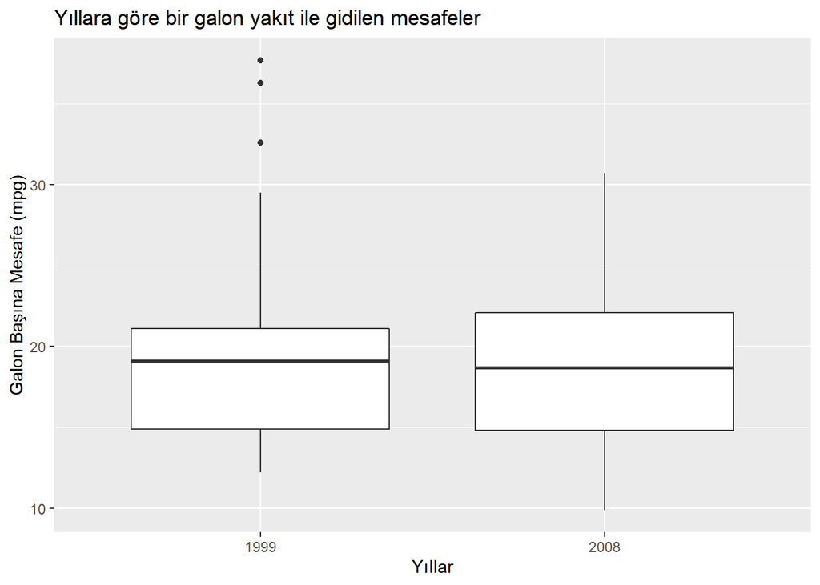

```r
mpg%>%group_by(year)%>%ggplot()+
  aes(x=year, y=mean_mpg)+
  geom_boxplot()+
  labs(
    x="Yıllar",
    y="Galon Başına Mesafe (mpg)",
    title = "Yıllara göre bir galon yakıt ile gidilen mesafeler"
    )
```

Yukarıdaki kutu grafiği de bir önceki bulgumuzu desteklemektedir. Ancak 1999 yılında bazı araçların (nokta ile gösterilen değerler) bir galon yakıt ile çok fazla mesafe gittiği görülmektedir.

Ortalamalar ve grafikler her ne kadar yıllar itibariyle araçların yakıt tüketimlerinde bir değişim olmadığı yönünde bir sonuca bizi götürsede kesin kararımızı ancak t testi yaparak verebiliriz. Bunun için “Yıllar itibari ile araçların bir galon yakıt ile gittikleri mesafe aynıdır” iddiasını araştırmamız gerekir. Bu iddia için sıfır ve alternatif hipotezleri aşağıdaki gibi kurabiliriz:

$$H_0: \mu_{1999}=\mu_{2008}\\
H_1: \mu_{1999} \ne \mu_{2008}$$

Burada $\mu_{1999}$ ve $\mu_{2008}$ araçların bir galon yakıt ile gittikleri ortalama mesafeleri temsil etmektedir.

Bu hipotezi `t.test()` fonksiyonunu kullanarak test edebiliriz. Bir galon benzin ile gidilen ortalama mesafeler (`mean_mpg`) test edilen değişken olmak üzere `~year` ifadesi ile bu değişken yıl bazında gruplara ayıralım. t testi ile iki grup arasında karşılaştırma yapılabileceğinden gruplama değişkeninde iki farklı seviye olmalıdır. `year` değişkeninde 1999 ve 2008 model araçlar olduğundan bu şart sağlanmaktadır.

```r
test=t.test(data=mpg, mean_mpg~year, var.equal=TRUE)
test
```

```
##
##  Two Sample t-test
##
## data:  mean_mpg by year
## t = 0.34588, df = 232, p-value = 0.7297
## alternative hypothesis: true difference in means between group 1999 and group 2008 is not equal to 0
## 95 percent confidence interval:
##  -1.003473  1.430824
## sample estimates:
## mean in group 1999 mean in group 2008
##           18.94017           18.72650
```

Yukarıdaki sonuçlarda $p_{değeri}=0.7297>0.05$ olduğundan $H_0$ hipotezi reddedilemez. Yıllara göre araçlaların ortalama mesafelerinde bir değişme olmamıştır.

İkinci olarak, otomatik vitesli araçların düz vitesli araçlara göre daha fazla yakıt tükkettiği şeklinde bir görüş vardır. Bu görüşün doğruluğunu araştırmak için otomatik ve düz vitesli araçların ortalama yakıt tüketimlerini hesaplayalım.

```r
mpg%>%group_by(trans)%>%
  summarise(mean=mean(mean_mpg))%>%
  knitr::kable(
    col.names=c("Vites Tipi", "Ortalama Mesafe"),
    digits = 3
    )%>%
  kable_styling(full_width = FALSE)
```

| Vites Tipi | Ortalama Mesafe |
| --- | --- |
| auto | 17.866 |
| manual | 20.806 |

Tablodan da görüldüğü düz vitesli araçlar galon başına ortalama 3 mil daha fazla yol yapmaktadır.

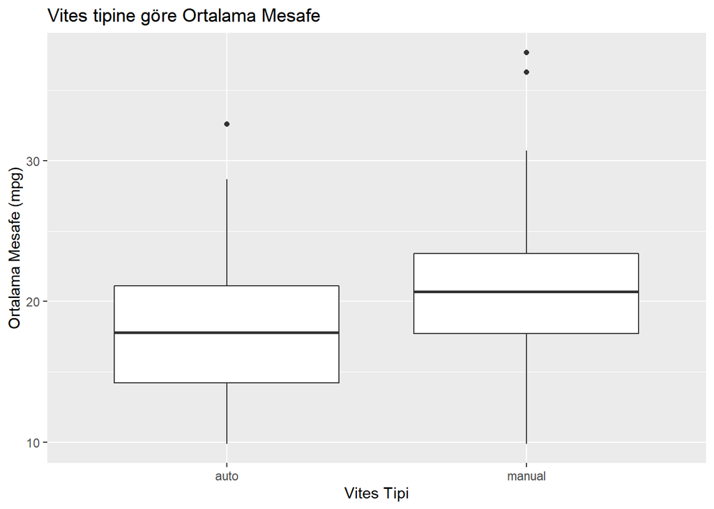

```r
ggplot(mpg)+
  aes(x=trans, y=mean_mpg)+
  geom_boxplot()+
  labs(
    x="Vites Tipi",
    y="Ortalama Mesafe (mpg)",
    title = "Vites tipine göre Ortalama Mesafe"
    )
```

```r
test2=t.test(data=mpg, mean_mpg~trans, var.equal=TRUE)
test2
```

```
##
##  Two Sample t-test
##
## data:  mean_mpg by trans
## t = -4.6788, df = 232, p-value = 4.905e-06
## alternative hypothesis: true difference in means between group auto and group manual is not equal to 0
## 95 percent confidence interval:
##  -4.179305 -1.702472
## sample estimates:
##   mean in group auto mean in group manual
##             17.86561             20.80649
```